# PS5

## Problem 1

$$y_i^* = 0.50 + 1.5x_{1i} - 2x_{2i} + u_i, \quad x_{1i}, x_{2i}, u_i \sim
normal(0,1)$$

$$y_i \sim Bernoulli(p_i), \quad p = \Phi(y_i^*)$$

### a.

1,000 observations of $y_i$ from the model above:

### b.

OLS regression of $y_i$ (not $y_i^*$) on $x_{1i}$ and $x_{2i}$ and plot of residuals:

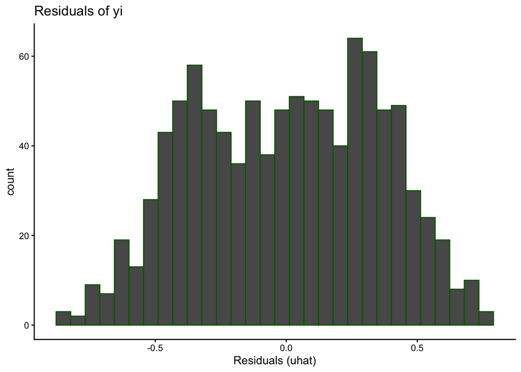

This plot doesn’t show a smooth distribution or very clearly normal distribution. Even though residuals look roughly centered around 0, they aren’t centered in the classic, unbumpy bell-shape. Residuals from this model can’t be normally distributed because the observed values of y are yes/no values (0-1), but in our model m1, we get fitted values of yhat that are not just 0-1 values, but values between 0 and 1, constraining/shaping residuals’ distribution.

### c.

Function that that repeats the following procedure 10,000 times: (1) generate $N$ observations of $y_i$, as in (a) above; (2) regress those $N$ observations on the two independent variables using `lm`; (3) store the estimated coefficient for $x_{1i}$ in a vector; (4) returns the vector of coefficient estimates at the end.

### e.

Use the functions `qqnorm` and `qqline`

#### For N = 10

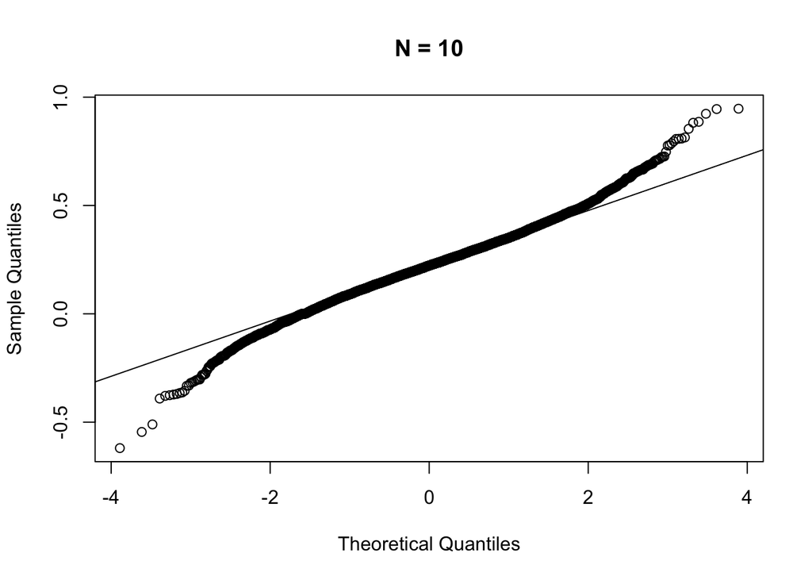

#### For N = 100

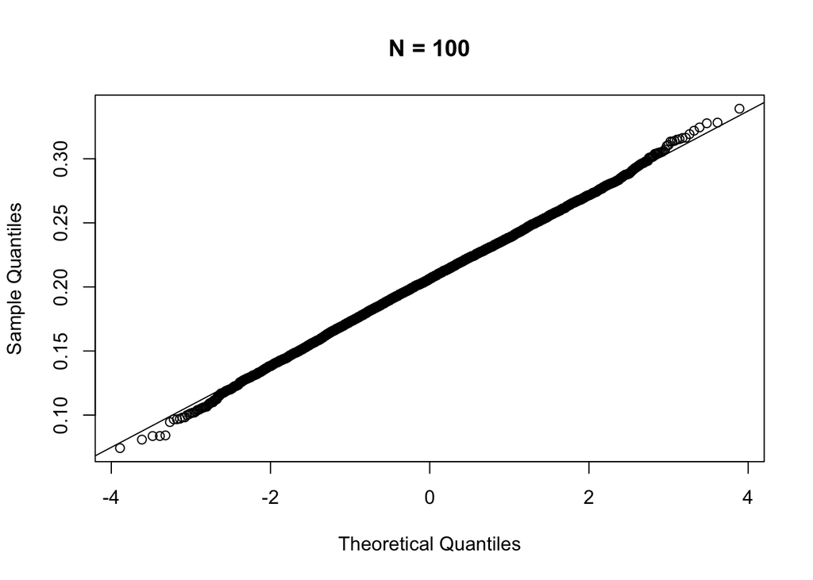

#### For N = 1,000

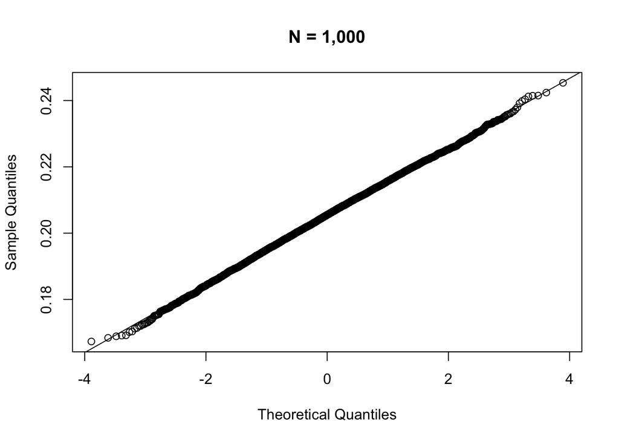

#### For N = 10,000

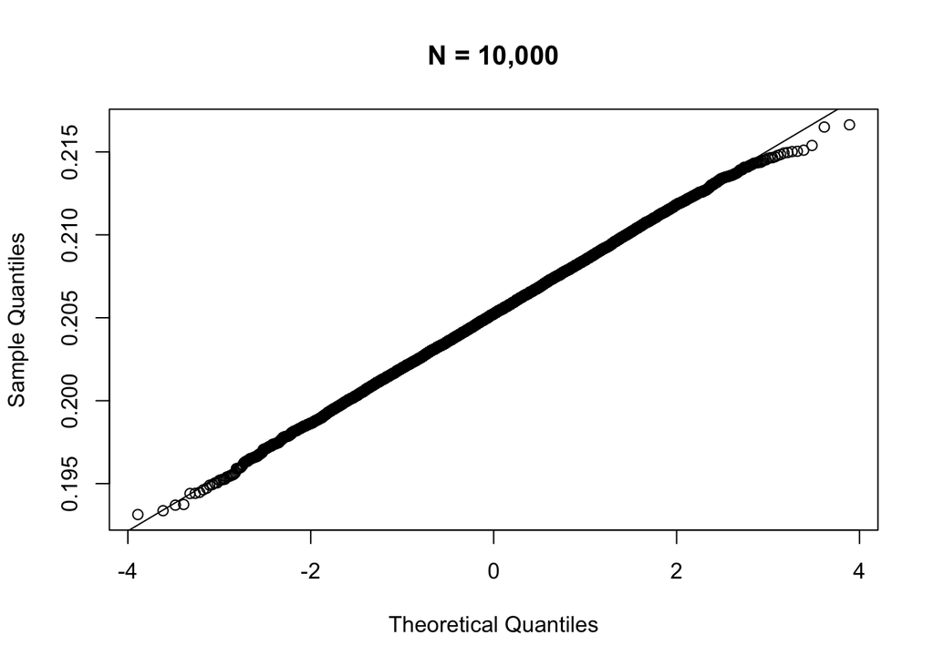

Assess how normal the distribution of estimated coefficients is for each of those sample sizes.

For N = 10, the estimated coefficient line noticably bows (is S-shaped) and has somewhat noisy tails – clear deviations from a straight line. But starting at N=100 samples the s-shape diminishes the points fix pretty close to the normalreference line. For N=1 and 10k, the points hug the line almost everwyere. The spread also shrinks as N increases, all suggesting the central limit theorem is driving asymptotic normality.

This happens even though the error term isn’t normally distributed because of the law of large numbers, whcih drives consistency (sample betas center on beta as N gets large), and also because of the central limit theorem: sampling distributions converge to the normal as N approaches infinity.